# Ciencia de Datos para Políticas Públicas

## Filtrar filas con `filter`

- Permite seleccionar un subconjunto de filas de un *data frame*
  - Ej: filas donde la columna `X` es mayor a `n`.
- Se pueden poner muchas condiciones de forma simple

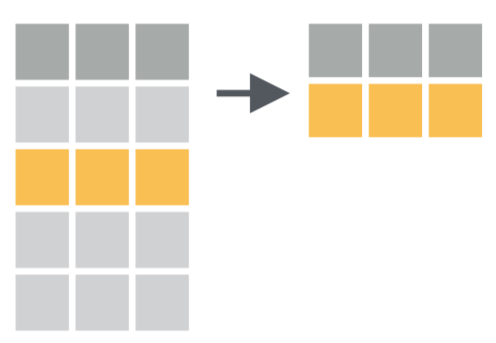

## `filter` (i)

Solo las observaciones correspondientes a Chile

```r
datosONU_tidy %>%
  filter(country_name == "Chile")
```

```
## # A tibble: 36 x 17
##    country_name income_group region  year co2_emissions_m~ fertility_rate_~
##    <chr>        <chr>        <chr>  <dbl>            <dbl>            <dbl>
##  1 Chile        High Income  Latin~  1972             2.84             3.68
##  2 Chile        High Income  Latin~  1973             2.74             3.50
##  3 Chile        High Income  Latin~  1974             2.53             3.33
##  4 Chile        High Income  Latin~  1975             2.21             3.16
##  5 Chile        High Income  Latin~  1976             2.28             3.01
##  6 Chile        High Income  Latin~  1977             2.15             2.89
##  7 Chile        High Income  Latin~  1978             2.11             2.79
##  8 Chile        High Income  Latin~  1979             2.25             2.72
##  9 Chile        High Income  Latin~  1980             2.26             2.68
## 10 Chile        High Income  Latin~  1981             2.16             2.66
## # ... with 26 more rows, and 11 more variables:
## #   forest_area_percent_of_land_area <dbl>,
## #   gdp_per_capita_constant_2005_us <dbl>,
## #   health_expenditure_per_capita_ppp_constant_2005_international <dbl>,
## #   labor_force_participation_rate_female_percent_of_female_population_ages_15_modeled_ilo_estimate <dbl>,
## #   life_expectancy_at_birth_total_years <dbl>,
## #   malnutrition_prevalence_weight_for_age_percent_of_children_under_5 <dbl>,
## #   population_total <dbl>, urban_population_percent_of_total <dbl>,
## #   fossil_fuel_energy_consumption_percent_of_total <dbl>,
## #   poverty_headcount_ratio_at_2_a_day_ppp_percent_of_population <dbl>,
## #   public_spending_on_education_total_percent_of_government_expenditure <dbl>
```

## `filter` (ii)

Solo las observaciones correspondientes a Chile y para años posteriores al 2000

```r
datosONU_tidy %>%
  filter(country_name == "Chile", year > 2000)
```

```
## # A tibble: 7 x 17
##   country_name income_group region  year co2_emissions_m~ fertility_rate_~
##   <chr>        <chr>        <chr>  <dbl>            <dbl>            <dbl>
## 1 Chile        High Income  Latin~  2001             3.37             2.05
## 2 Chile        High Income  Latin~  2002             3.50             2.01
## 3 Chile        High Income  Latin~  2003             3.44             1.98
## 4 Chile        High Income  Latin~  2004             3.71             1.96
## 5 Chile        High Income  Latin~  2005             3.78             1.94
## 6 Chile        High Income  Latin~  2006             3.90             1.92
## 7 Chile        High Income  Latin~  2007             4.27             1.90
## # ... with 11 more variables: forest_area_percent_of_land_area <dbl>,
## #   gdp_per_capita_constant_2005_us <dbl>,
## #   health_expenditure_per_capita_ppp_constant_2005_international <dbl>,
## #   labor_force_participation_rate_female_percent_of_female_population_ages_15_modeled_ilo_estimate <dbl>,
## #   life_expectancy_at_birth_total_years <dbl>,
## #   malnutrition_prevalence_weight_for_age_percent_of_children_under_5 <dbl>,
## #   population_total <dbl>, urban_population_percent_of_total <dbl>,
## #   fossil_fuel_energy_consumption_percent_of_total <dbl>,
## #   poverty_headcount_ratio_at_2_a_day_ppp_percent_of_population <dbl>,
## #   public_spending_on_education_total_percent_of_government_expenditure <dbl>
```

## `filter` (iii)

Solo las observaciones correspondientes al 2000 o al 2007

```r
datosONU_tidy %>%
  filter(year == 2000 | year == 2007)
```

```
## # A tibble: 428 x 17
##    country_name income_group region  year co2_emissions_m~ fertility_rate_~
##    <chr>        <chr>        <chr>  <dbl>            <dbl>            <dbl>
##  1 Afghanistan  Low Income   South~  2000           0.0379             7.73
##  2 Afghanistan  Low Income   South~  2007           0.0756             6.46
##  3 Albania      Upper Middl~ Europ~  2000           0.978              2.38
##  4 Albania      Upper Middl~ Europ~  2007           1.38               1.80
##  5 Algeria      Upper Middl~ Middl~  2000           2.77               2.51
##  6 Algeria      Upper Middl~ Middl~  2007           3.20               2.66
##  7 American Sa~ Upper Middl~ East ~  2000          NA                 NA
##  8 American Sa~ Upper Middl~ East ~  2007          NA                 NA
##  9 Andorra      High Income  Europ~  2000           8.02              NA
## 10 Andorra      High Income  Europ~  2007           6.63               1.18
## # ... with 418 more rows, and 11 more variables:
## #   forest_area_percent_of_land_area <dbl>,
## #   gdp_per_capita_constant_2005_us <dbl>,
## #   health_expenditure_per_capita_ppp_constant_2005_international <dbl>,
## #   labor_force_participation_rate_female_percent_of_female_population_ages_15_modeled_ilo_estimate <dbl>,
## #   life_expectancy_at_birth_total_years <dbl>,
## #   malnutrition_prevalence_weight_for_age_percent_of_children_under_5 <dbl>,
## #   population_total <dbl>, urban_population_percent_of_total <dbl>,
## #   fossil_fuel_energy_consumption_percent_of_total <dbl>,
## #   poverty_headcount_ratio_at_2_a_day_ppp_percent_of_population <dbl>,
## #   public_spending_on_education_total_percent_of_government_expenditure <dbl>
```

## Operadores lógicos comúnmente usados (i)

| Operador | Definición |
| --- | --- |
| `<` | menor |
| `<=` | menor o igual |
| `>` | mayor |
| `>=` | mayor o igual |
| `==` | estríctamente igual |
| `!=` | distinto |
| `x\|y` | x O y |
| `x&y` | x Y y |

## Operadores lógicos comúnmente usados (ii)

| Operador | Definición |
| --- | --- |
| `is.na(x)` | test: valor NA (nulo) |
| `!is.na(x)` | test: no es valor NA (nulo) |
| `x %in% y` | x perteneciente a y |
| `!(x %in% y)` | todo lo perteneciente a y que no es x |
| `!x` | no x |

## `filter` (iv)

Solo las observaciones correspondientes a los años 1995, 2000, y 2005

```r
datosONU_tidy %>%
  filter(year %in% c(1995, 2000, 2005))
```

```
## # A tibble: 642 x 17
##    country_name income_group region  year co2_emissions_m~ fertility_rate_~
##    <chr>        <chr>        <chr>  <dbl>            <dbl>            <dbl>
##  1 Afghanistan  Low Income   South~  1995           0.0721             7.83
##  2 Afghanistan  Low Income   South~  2000           0.0379             7.73
##  3 Afghanistan  Low Income   South~  2005           0.0409             6.93
##  4 Albania      Upper Middl~ Europ~  1995           0.655              2.72
##  5 Albania      Upper Middl~ Europ~  2000           0.978              2.38
##  6 Albania      Upper Middl~ Europ~  2005           1.42               1.92
##  7 Algeria      Upper Middl~ Middl~  1995           3.23               3.45
##  8 Algeria      Upper Middl~ Middl~  2000           2.77               2.51
##  9 Algeria      Upper Middl~ Middl~  2005           3.15               2.51
## 10 American Sa~ Upper Middl~ East ~  1995          NA                 NA
## # ... with 632 more rows, and 11 more variables:
## #   forest_area_percent_of_land_area <dbl>,
## #   gdp_per_capita_constant_2005_us <dbl>,
## #   health_expenditure_per_capita_ppp_constant_2005_international <dbl>,
## #   labor_force_participation_rate_female_percent_of_female_population_ages_15_modeled_ilo_estimate <dbl>,
## #   life_expectancy_at_birth_total_years <dbl>,
## #   malnutrition_prevalence_weight_for_age_percent_of_children_under_5 <dbl>,
## #   population_total <dbl>, urban_population_percent_of_total <dbl>,
## #   fossil_fuel_energy_consumption_percent_of_total <dbl>,
## #   poverty_headcount_ratio_at_2_a_day_ppp_percent_of_population <dbl>,
## #   public_spending_on_education_total_percent_of_government_expenditure <dbl>
```

## `filter` (v)

Solo las observaciones **NO** correspondientes a los años 1995, 2000, y 2005

```r
datosONU_tidy %>%
  filter(!year %in% c(1995, 2000, 2005))
```

```
## # A tibble: 7,062 x 17
##    country_name income_group region  year co2_emissions_m~ fertility_rate_~
##    <chr>        <chr>        <chr>  <dbl>            <dbl>            <dbl>
##  1 Afghanistan  Low Income   South~  1972            0.132             7.67
##  2 Afghanistan  Low Income   South~  1973            0.137             7.67
##  3 Afghanistan  Low Income   South~  1974            0.156             7.67
##  4 Afghanistan  Low Income   South~  1975            0.169             7.67
##  5 Afghanistan  Low Income   South~  1976            0.155             7.67
##  6 Afghanistan  Low Income   South~  1977            0.183             7.67
##  7 Afghanistan  Low Income   South~  1978            0.164             7.67
##  8 Afghanistan  Low Income   South~  1979            0.169             7.67
##  9 Afghanistan  Low Income   South~  1980            0.134             7.67
## 10 Afghanistan  Low Income   South~  1981            0.153             7.67
## # ... with 7,052 more rows, and 11 more variables:
## #   forest_area_percent_of_land_area <dbl>,
## #   gdp_per_capita_constant_2005_us <dbl>,
## #   health_expenditure_per_capita_ppp_constant_2005_international <dbl>,
## #   labor_force_participation_rate_female_percent_of_female_population_ages_15_modeled_ilo_estimate <dbl>,
## #   life_expectancy_at_birth_total_years <dbl>,
## #   malnutrition_prevalence_weight_for_age_percent_of_children_under_5 <dbl>,
## #   population_total <dbl>, urban_population_percent_of_total <dbl>,
## #   fossil_fuel_energy_consumption_percent_of_total <dbl>,
## #   poverty_headcount_ratio_at_2_a_day_ppp_percent_of_population <dbl>,
## #   public_spending_on_education_total_percent_of_government_expenditure <dbl>
```

## `slice` para seleccionar filas por posición (i)

La quinta fila

```r
datosONU_tidy %>%
  slice(5)
```

```
## # A tibble: 1 x 17
##   country_name income_group region  year co2_emissions_m~ fertility_rate_~
##   <chr>        <chr>        <chr>  <dbl>            <dbl>            <dbl>
## 1 Afghanistan  Low Income   South~  1976            0.155             7.67
## # ... with 11 more variables: forest_area_percent_of_land_area <dbl>,
## #   gdp_per_capita_constant_2005_us <dbl>,
## #   health_expenditure_per_capita_ppp_constant_2005_international <dbl>,
## #   labor_force_participation_rate_female_percent_of_female_population_ages_15_modeled_ilo_estimate <dbl>,
## #   life_expectancy_at_birth_total_years <dbl>,
## #   malnutrition_prevalence_weight_for_age_percent_of_children_under_5 <dbl>,
## #   population_total <dbl>, urban_population_percent_of_total <dbl>,
## #   fossil_fuel_energy_consumption_percent_of_total <dbl>,
## #   poverty_headcount_ratio_at_2_a_day_ppp_percent_of_population <dbl>,
## #   public_spending_on_education_total_percent_of_government_expenditure <dbl>
```

## `slice` para seleccionar filas por posición (ii)

Las primeras 5 filas

```r
datosONU_tidy %>%
  slice(1:5)
```

```
## # A tibble: 5 x 17
##   country_name income_group region  year co2_emissions_m~ fertility_rate_~
##   <chr>        <chr>        <chr>  <dbl>            <dbl>            <dbl>
## 1 Afghanistan  Low Income   South~  1972            0.132             7.67
## 2 Afghanistan  Low Income   South~  1973            0.137             7.67
## 3 Afghanistan  Low Income   South~  1974            0.156             7.67
## 4 Afghanistan  Low Income   South~  1975            0.169             7.67
## 5 Afghanistan  Low Income   South~  1976            0.155             7.67
## # ... with 11 more variables: forest_area_percent_of_land_area <dbl>,
## #   gdp_per_capita_constant_2005_us <dbl>,
## #   health_expenditure_per_capita_ppp_constant_2005_international <dbl>,
## #   labor_force_participation_rate_female_percent_of_female_population_ages_15_modeled_ilo_estimate <dbl>,
## #   life_expectancy_at_birth_total_years <dbl>,
## #   malnutrition_prevalence_weight_for_age_percent_of_children_under_5 <dbl>,
## #   population_total <dbl>, urban_population_percent_of_total <dbl>,
## #   fossil_fuel_energy_consumption_percent_of_total <dbl>,
## #   poverty_headcount_ratio_at_2_a_day_ppp_percent_of_population <dbl>,
## #   public_spending_on_education_total_percent_of_government_expenditure <dbl>
```

## Seleccionar columnas/variables con `select`

- Permite seleccionar un subconjunto de columnas de un *data frame*
  - U ordenarlas de una forma en particular
- Se pueden seleccionar por nombre o por posición

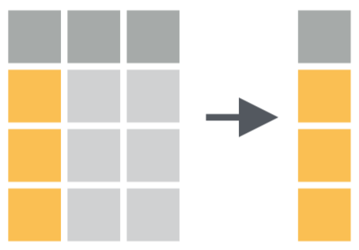

## `select` (i)

Seleccionar 5 variables/columnas

```r
datosONU_tidy %>%
  select(country_name, income_group, region, year, population_total)
```

```
## # A tibble: 7,704 x 5
##    country_name income_group region      year population_total
##    <chr>        <chr>        <chr>      <dbl>            <dbl>
##  1 Afghanistan  Low Income   South Asia  1972         11644377
##  2 Afghanistan  Low Income   South Asia  1973         11966352
##  3 Afghanistan  Low Income   South Asia  1974         12273589
##  4 Afghanistan  Low Income   South Asia  1975         12551790
##  5 Afghanistan  Low Income   South Asia  1976         12806810
##  6 Afghanistan  Low Income   South Asia  1977         13034460
##  7 Afghanistan  Low Income   South Asia  1978         13199597
##  8 Afghanistan  Low Income   South Asia  1979         13257128
##  9 Afghanistan  Low Income   South Asia  1980         13180431
## 10 Afghanistan  Low Income   South Asia  1981         12963788
## # ... with 7,694 more rows
```

## `select` (ii)

Dejar todas las columnas menos dos

```r
datosONU_tidy %>%
  select(-region, -income_group)
```

```
## # A tibble: 7,704 x 15
##    country_name  year co2_emissions_m~ fertility_rate_~ forest_area_per~
##    <chr>        <dbl>            <dbl>            <dbl>            <dbl>
##  1 Afghanistan   1972            0.132             7.67               NA
##  2 Afghanistan   1973            0.137             7.67               NA
##  3 Afghanistan   1974            0.156             7.67               NA
##  4 Afghanistan   1975            0.169             7.67               NA
##  5 Afghanistan   1976            0.155             7.67               NA
##  6 Afghanistan   1977            0.183             7.67               NA
##  7 Afghanistan   1978            0.164             7.67               NA
##  8 Afghanistan   1979            0.169             7.67               NA
##  9 Afghanistan   1980            0.134             7.67               NA
## 10 Afghanistan   1981            0.153             7.67               NA
## # ... with 7,694 more rows, and 10 more variables:
## #   gdp_per_capita_constant_2005_us <dbl>,
## #   health_expenditure_per_capita_ppp_constant_2005_international <dbl>,
## #   labor_force_participation_rate_female_percent_of_female_population_ages_15_modeled_ilo_estimate <dbl>,
## #   life_expectancy_at_birth_total_years <dbl>,
## #   malnutrition_prevalence_weight_for_age_percent_of_children_under_5 <dbl>,
## #   population_total <dbl>, urban_population_percent_of_total <dbl>,
## #   fossil_fuel_energy_consumption_percent_of_total <dbl>,
## #   poverty_headcount_ratio_at_2_a_day_ppp_percent_of_population <dbl>,
## #   public_spending_on_education_total_percent_of_government_expenditure <dbl>
```

## `select` tiene varias funciones “de ayuda” (i)

Dejar todas las columnas que contengan *per capita*

```r
datosONU_tidy %>%
  select(contains("per_capita"))
```

```
## # A tibble: 7,704 x 3
##    co2_emissions_metric_t~ gdp_per_capita_const~ health_expenditure_per_capita_~
##                      <dbl>                 <dbl>                           <dbl>
##  1                   0.132                    NA                              NA
##  2                   0.137                    NA                              NA
##  3                   0.156                    NA                              NA
##  4                   0.169                    NA                              NA
##  5                   0.155                    NA                              NA
##  6                   0.183                    NA                              NA
##  7                   0.164                    NA                              NA
##  8                   0.169                    NA                              NA
##  9                   0.134                    NA                              NA
## 10                   0.153                    NA                              NA
## # ... with 7,694 more rows
```

## `select` tiene varias funciones “de ayuda” (ii)

Dejar todas las columnas que comiencen con *p*

```r
datosONU_tidy %>%
  select(starts_with("p"))
```

```
## # A tibble: 7,704 x 3
##    population_total poverty_headcount_ratio_at_2~ public_spending_on_education_~
##               <dbl>                         <dbl>                          <dbl>
##  1         11644377                            NA                             NA
##  2         11966352                            NA                             NA
##  3         12273589                            NA                             NA
##  4         12551790                            NA                             NA
##  5         12806810                            NA                             NA
##  6         13034460                            NA                             NA
##  7         13199597                            NA                             NA
##  8         13257128                            NA                             NA
##  9         13180431                            NA                             NA
## 10         12963788                            NA                             NA
## # ... with 7,694 more rows
```

## `select` tiene varias funciones “de ayuda” (iii)

Dejar todas las columnas numéricas

```r
datosONU_tidy %>%
  select(where(is.numeric))
```

```
## # A tibble: 7,704 x 14
##     year co2_emissions_m~ fertility_rate_~ forest_area_per~ gdp_per_capita_~
##    <dbl>            <dbl>            <dbl>            <dbl>            <dbl>
##  1  1972            0.132             7.67               NA               NA
##  2  1973            0.137             7.67               NA               NA
##  3  1974            0.156             7.67               NA               NA
##  4  1975            0.169             7.67               NA               NA
##  5  1976            0.155             7.67               NA               NA
##  6  1977            0.183             7.67               NA               NA
##  7  1978            0.164             7.67               NA               NA
##  8  1979            0.169             7.67               NA               NA
##  9  1980            0.134             7.67               NA               NA
## 10  1981            0.153             7.67               NA               NA
## # ... with 7,694 more rows, and 9 more variables:
## #   health_expenditure_per_capita_ppp_constant_2005_international <dbl>,
## #   labor_force_participation_rate_female_percent_of_female_population_ages_15_modeled_ilo_estimate <dbl>,
## #   life_expectancy_at_birth_total_years <dbl>,
## #   malnutrition_prevalence_weight_for_age_percent_of_children_under_5 <dbl>,
## #   population_total <dbl>, urban_population_percent_of_total <dbl>,
## #   fossil_fuel_energy_consumption_percent_of_total <dbl>,
## #   poverty_headcount_ratio_at_2_a_day_ppp_percent_of_population <dbl>,
## #   public_spending_on_education_total_percent_of_government_expenditure <dbl>
```

## Crear columnas/variables con `mutate`

- Permite generar nuevas columnas/variables en un *data frame*
  - Ej: nueva columna `Z` igual a la división entre las columnas `X` e `Y`
- Nuevas columnas pueden o no depender de columnas ya existentes
- Se pueden generar más de una columna en un comando

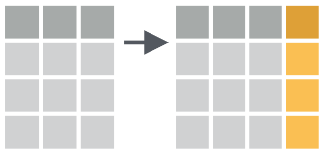

## `mutate` para agregar nuevas columnas

Nueva columna calculando el logaritmo de una existente

```r
datosONU_tidy %>%
  select(country_name, year, co2_emissions_metric_tons_per_capita) %>%
  mutate(log_co2_emissions = log(co2_emissions_metric_tons_per_capita))
```

```
## # A tibble: 7,704 x 4
##    country_name  year co2_emissions_metric_tons_per_capita log_co2_emissions
##    <chr>        <dbl>                                <dbl>             <dbl>
##  1 Afghanistan   1972                                0.132             -2.03
##  2 Afghanistan   1973                                0.137             -1.99
##  3 Afghanistan   1974                                0.156             -1.86
##  4 Afghanistan   1975                                0.169             -1.78
##  5 Afghanistan   1976                                0.155             -1.86
##  6 Afghanistan   1977                                0.183             -1.70
##  7 Afghanistan   1978                                0.164             -1.81
##  8 Afghanistan   1979                                0.169             -1.78
##  9 Afghanistan   1980                                0.134             -2.01
## 10 Afghanistan   1981                                0.153             -1.88
## # ... with 7,694 more rows
```

## `rename` para cambiar nombres de columnas/variables (i)

Nombres muy largos

```r
names(datosONU_tidy)
```

```
##  [1] "country_name"
##  [2] "income_group"
##  [3] "region"
##  [4] "year"
##  [5] "co2_emissions_metric_tons_per_capita"
##  [6] "fertility_rate_total_births_per_woman"
##  [7] "forest_area_percent_of_land_area"
##  [8] "gdp_per_capita_constant_2005_us"
##  [9] "health_expenditure_per_capita_ppp_constant_2005_international"
## [10] "labor_force_participation_rate_female_percent_of_female_population_ages_15_modeled_ilo_estimate"
## [11] "life_expectancy_at_birth_total_years"
## [12] "malnutrition_prevalence_weight_for_age_percent_of_children_under_5"
## [13] "population_total"
## [14] "urban_population_percent_of_total"
## [15] "fossil_fuel_energy_consumption_percent_of_total"
## [16] "poverty_headcount_ratio_at_2_a_day_ppp_percent_of_population"
## [17] "public_spending_on_education_total_percent_of_government_expenditure"
```

## `rename` para cambiar nombres de columnas/variables (ii)

Estructura a seguir

```r
rename(datos, NuevoNombre = AntiguoNombre)
```

## `rename` para cambiar nombres de columnas/variables (iii)

```r
datosONU_tidy %>%
  rename(
    "co2_emissions" = "co2_emissions_metric_tons_per_capita",
    "fertility_rate" = "fertility_rate_total_births_per_woman",
    "forest_area" = "forest_area_percent_of_land_area",
    "gdp_per_capita" = "gdp_per_capita_constant_2005_us",
    "health_expenditure" = "health_expenditure_per_capita_ppp_constant_2005_international",
    "labor_force_participation" = "labor_force_participation_rate_female_percent_of_female_population_ages_15_modeled_ilo_estimate",
    "life_expectancy" = "life_expectancy_at_birth_total_years",
    "malnutrition_prevalence" = "malnutrition_prevalence_weight_for_age_percent_of_children_under_5",
    "urban_population" = "urban_population_percent_of_total",
    "fossil_fuel_consumption" = "fossil_fuel_energy_consumption_percent_of_total",
    "poverty" = "poverty_headcount_ratio_at_2_a_day_ppp_percent_of_population",
    "public_spending_education" = "public_spending_on_education_total_percent_of_government_expenditure"
  )
```

## No olvidar “guardar” los resultados (i)

Generalmente cuando generemos cambios en nuestro *dara frame* (`filter`, `select`, `mutate`) también queremos guardar el *data frame* resultante. Esto se puede hacer “sobreescribiendo” el *data frame* original o bien creando uno nuevo

Sobreescribir *data frame*

```r
datosONU_tidy <- datosONU_tidy %>%
  rename(
    "co2_emissions" = "co2_emissions_metric_tons_per_capita",
    "fertility_rate" = "fertility_rate_total_births_per_woman",
    "forest_area" = "forest_area_percent_of_land_area",
    "gdp_per_capita" = "gdp_per_capita_constant_2005_us",
    "health_expenditure" = "health_expenditure_per_capita_ppp_constant_2005_international",
    "labor_force_participation" = "labor_force_participation_rate_female_percent_of_female_population_ages_15_modeled_ilo_estimate",
    "life_expectancy" = "life_expectancy_at_birth_total_years",
    "malnutrition_prevalence" = "malnutrition_prevalence_weight_for_age_percent_of_children_under_5",
    "urban_population" = "urban_population_percent_of_total",
    "fossil_fuel_consumption" = "fossil_fuel_energy_consumption_percent_of_total",
    "poverty" = "poverty_headcount_ratio_at_2_a_day_ppp_percent_of_population",
    "public_spending_education" = "public_spending_on_education_total_percent_of_government_expenditure"
  )
```

## No olvidar “guardar” los resultados (ii)

Crear nuevo *data frame*

```r
datosONU_tidy_nuevo <- datosONU_tidy %>%
  rename(
    "co2_emissions" = "co2_emissions_metric_tons_per_capita",
    "fertility_rate" = "fertility_rate_total_births_per_woman",
    "forest_area" = "forest_area_percent_of_land_area",
    "gdp_per_capita" = "gdp_per_capita_constant_2005_us",
    "health_expenditure" = "health_expenditure_per_capita_ppp_constant_2005_international",
    "labor_force_participation" = "labor_force_participation_rate_female_percent_of_female_population_ages_15_modeled_ilo_estimate",
    "life_expectancy" = "life_expectancy_at_birth_total_years",
    "malnutrition_prevalence" = "malnutrition_prevalence_weight_for_age_percent_of_children_under_5",
    "urban_population" = "urban_population_percent_of_total",
    "fossil_fuel_consumption" = "fossil_fuel_energy_consumption_percent_of_total",
    "poverty" = "poverty_headcount_ratio_at_2_a_day_ppp_percent_of_population",
    "public_spending_education" = "public_spending_on_education_total_percent_of_government_expenditure"
  )
```

## Revisar resultado del cambio de nombre

```r
names(datosONU_tidy)
```

```
##  [1] "country_name"              "income_group"
##  [3] "region"                    "year"
##  [5] "co2_emissions"             "fertility_rate"
##  [7] "forest_area"               "gdp_per_capita"
##  [9] "health_expenditure"        "labor_force_participation"
## [11] "life_expectancy"           "malnutrition_prevalence"
## [13] "population_total"          "urban_population"
## [15] "fossil_fuel_consumption"   "poverty"
## [17] "public_spending_education"
```

## `arrange` para ordenar filas según columnas (i)

```r
datosONU_tidy
```

```
## # A tibble: 7,704 x 17
##    country_name income_group region  year co2_emissions fertility_rate
##    <chr>        <chr>        <chr>  <dbl>         <dbl>          <dbl>
##  1 Afghanistan  Low Income   South~  1972         0.132           7.67
##  2 Afghanistan  Low Income   South~  1973         0.137           7.67
##  3 Afghanistan  Low Income   South~  1974         0.156           7.67
##  4 Afghanistan  Low Income   South~  1975         0.169           7.67
##  5 Afghanistan  Low Income   South~  1976         0.155           7.67
##  6 Afghanistan  Low Income   South~  1977         0.183           7.67
##  7 Afghanistan  Low Income   South~  1978         0.164           7.67
##  8 Afghanistan  Low Income   South~  1979         0.169           7.67
##  9 Afghanistan  Low Income   South~  1980         0.134           7.67
## 10 Afghanistan  Low Income   South~  1981         0.153           7.67
## # ... with 7,694 more rows, and 11 more variables: forest_area <dbl>,
## #   gdp_per_capita <dbl>, health_expenditure <dbl>,
## #   labor_force_participation <dbl>, life_expectancy <dbl>,
## #   malnutrition_prevalence <dbl>, population_total <dbl>,
## #   urban_population <dbl>, fossil_fuel_consumption <dbl>, poverty <dbl>,
## #   public_spending_education <dbl>
```

## `arrange` para ordenar filas según columnas (ii)

```r
datosONU_tidy %>%
  arrange(year)
```

```
## # A tibble: 7,704 x 17
##    country_name income_group region  year co2_emissions fertility_rate
##    <chr>        <chr>        <chr>  <dbl>         <dbl>          <dbl>
##  1 Afghanistan  Low Income   South~  1972         0.132           7.67
##  2 Albania      Upper Middl~ Europ~  1972         2.52            4.81
##  3 Algeria      Upper Middl~ Middl~  1972         1.83            7.59
##  4 American Sa~ Upper Middl~ East ~  1972        NA              NA
##  5 Andorra      High Income  Europ~  1972        NA              NA
##  6 Angola       Lower Middl~ Sub-s~  1972         0.729           7.23
##  7 Antigua and~ High Income  Latin~  1972         5.57            3.33
##  8 Argentina    Upper Middl~ Latin~  1972         3.64            3.15
##  9 Armenia      Upper Middl~ Europ~  1972        NA               3.03
## 10 Aruba        High Income  Latin~  1972        NA               2.69
## # ... with 7,694 more rows, and 11 more variables: forest_area <dbl>,
## #   gdp_per_capita <dbl>, health_expenditure <dbl>,
## #   labor_force_participation <dbl>, life_expectancy <dbl>,
## #   malnutrition_prevalence <dbl>, population_total <dbl>,
## #   urban_population <dbl>, fossil_fuel_consumption <dbl>, poverty <dbl>,
## #   public_spending_education <dbl>
```

## `arrange` para ordenar filas según columnas (iii)

```r
datosONU_tidy %>%
  arrange(-year, income_group)
```

```
## # A tibble: 7,704 x 17
##    country_name income_group region  year co2_emissions fertility_rate
##    <chr>        <chr>        <chr>  <dbl>         <dbl>          <dbl>
##  1 Andorra      High Income  Europ~  2007          6.63           1.18
##  2 Antigua and~ High Income  Latin~  2007          5.26           2.18
##  3 Aruba        High Income  Latin~  2007         23.3            1.74
##  4 Australia    High Income  East ~  2007         18.1            1.96
##  5 Austria      High Income  Europ~  2007          8.33           1.38
##  6 Bahamas, The High Income  Latin~  2007          4.52           1.88
##  7 Bahrain      High Income  Middl~  2007         21.7            2.29
##  8 Barbados     High Income  Latin~  2007          5.16           1.83
##  9 Belgium      High Income  Europ~  2007          9.71           1.82
## 10 Bermuda      High Income  North~  2007          7.97           1.76
## # ... with 7,694 more rows, and 11 more variables: forest_area <dbl>,
## #   gdp_per_capita <dbl>, health_expenditure <dbl>,
## #   labor_force_participation <dbl>, life_expectancy <dbl>,
## #   malnutrition_prevalence <dbl>, population_total <dbl>,
## #   urban_population <dbl>, fossil_fuel_consumption <dbl>, poverty <dbl>,
## #   public_spending_education <dbl>
```

## `distinct` para dejar valores únicos (i)

Tantos valores como observaciones hay

```r
datosONU_tidy %>%
  select(income_group)
```

```
## # A tibble: 7,704 x 1
##    income_group
##    <chr>
##  1 Low Income
##  2 Low Income
##  3 Low Income
##  4 Low Income
##  5 Low Income
##  6 Low Income
##  7 Low Income
##  8 Low Income
##  9 Low Income
## 10 Low Income
## # ... with 7,694 more rows
```

## `distinct` para dejar valores únicos (ii)

Pero son pocos valores únicos/distintos

```r
datosONU_tidy %>%
  select(income_group) %>%
  distinct()
```

```
## # A tibble: 4 x 1
##   income_group
##   <chr>
## 1 Low Income
## 2 Upper Middle Income
## 3 High Income
## 4 Lower Middle Income
```

## `distinct` para dejar valores únicos (iii)

Se puede hacer para cualquier combinación de columnas/variables

```r
datosONU_tidy %>%
  select(income_group, region) %>%
  distinct() %>%
  arrange(income_group, region)
```

```
## # A tibble: 24 x 2
##    income_group region
##    <chr>        <chr>
##  1 High Income  East Asia and Pacific
##  2 High Income  Europe and Central Afica
##  3 High Income  Latin America and the Caribbean
##  4 High Income  Middle East and North Africa
##  5 High Income  North America
##  6 High Income  Sub-saharan Africa
##  7 Low Income   East Asia and Pacific
##  8 Low Income   Europe and Central Afica
##  9 Low Income   Latin America and the Caribbean
## 10 Low Income   Middle East and North Africa
## # ... with 14 more rows
```

## `summarise` para reducir variables a valores (i)

Número de observaciones

```r
datosONU_tidy %>%
  summarise(n_observaciones = n())
```

```
## # A tibble: 1 x 1
##   n_observaciones
##             <int>
## 1            7704
```

Promedio de la columna *fertility_rate*

```r
datosONU_tidy %>%
  summarise(promedio_fertility_rate =
              mean(fertility_rate, na.rm = TRUE))
```

```
## # A tibble: 1 x 1
##   promedio_fertility_rate
##                     <dbl>
## 1                    3.95
```

Número de países

```r
datosONU_tidy %>%
  summarise(n_paises = n_distinct(country_name))
```

```
## # A tibble: 1 x 1
##   n_paises
##      <int>
## 1      214
```

Máximo valor de *gdp_per_capita*

```r
datosONU_tidy %>%
  summarise(max_gdp_per_capita =
              max(gdp_per_capita, na.rm = TRUE))
```

```
## # A tibble: 1 x 1
##   max_gdp_per_capita
##                <dbl>
## 1            147141.
```

## `summarise` para reducir variables a valores (ii)

Se puede calcular más de un valor a la vez

```r
datosONU_tidy %>%
  summarise(n_observaciones = n(),
            n_paises = n_distinct(country_name),
            promedio_fertility_rate = mean(fertility_rate, na.rm = TRUE),
            max_gdp_per_capita = max(gdp_per_capita, na.rm = TRUE))
```

```
## # A tibble: 1 x 4
##   n_observaciones n_paises promedio_fertility_rate max_gdp_per_capita
##             <int>    <int>                   <dbl>              <dbl>
## 1            7704      214                    3.95            147141.
```

## `group_by` para agrupar observaciones (i)

Por si sola no pasa nada

```r
datosONU_tidy %>%
  group_by(region)
```

```
## # A tibble: 7,704 x 17
## # Groups:   region [7]
##    country_name income_group region  year co2_emissions fertility_rate
##    <chr>        <chr>        <chr>  <dbl>         <dbl>          <dbl>
##  1 Afghanistan  Low Income   South~  1972         0.132           7.67
##  2 Afghanistan  Low Income   South~  1973         0.137           7.67
##  3 Afghanistan  Low Income   South~  1974         0.156           7.67
##  4 Afghanistan  Low Income   South~  1975         0.169           7.67
##  5 Afghanistan  Low Income   South~  1976         0.155           7.67
##  6 Afghanistan  Low Income   South~  1977         0.183           7.67
##  7 Afghanistan  Low Income   South~  1978         0.164           7.67
##  8 Afghanistan  Low Income   South~  1979         0.169           7.67
##  9 Afghanistan  Low Income   South~  1980         0.134           7.67
## 10 Afghanistan  Low Income   South~  1981         0.153           7.67
## # ... with 7,694 more rows, and 11 more variables: forest_area <dbl>,
## #   gdp_per_capita <dbl>, health_expenditure <dbl>,
## #   labor_force_participation <dbl>, life_expectancy <dbl>,
## #   malnutrition_prevalence <dbl>, population_total <dbl>,
## #   urban_population <dbl>, fossil_fuel_consumption <dbl>, poverty <dbl>,
## #   public_spending_education <dbl>
```

## `group_by` para agrupar observaciones (ii)

Pero con `summarise` aparecen las ventajas

```r
datosONU_tidy %>%
  group_by(region) %>%
  summarise(n_observaciones = n())
```

```
## # A tibble: 7 x 2
##   region                          n_observaciones
##   <chr>                                     <int>
## 1 East Asia and Pacific                      1296
## 2 Europe and Central Afica                   2052
## 3 Latin America and the Caribbean            1476
## 4 Middle East and North Africa                756
## 5 North America                               108
## 6 South Asia                                  288
## 7 Sub-saharan Africa                         1728
```

```r
datosONU_tidy %>%
  group_by(region) %>%
  summarise(n_paises = n_distinct(country_name))
```

```
## # A tibble: 7 x 2
##   region                          n_paises
##   <chr>                              <int>
## 1 East Asia and Pacific                 36
## 2 Europe and Central Afica              57
## 3 Latin America and the Caribbean       41
## 4 Middle East and North Africa          21
## 5 North America                          3
## 6 South Asia                             8
## 7 Sub-saharan Africa                    48
```

## `group_by` para agrupar observaciones (iii)

Se puede agrupar por más de una variable/columna

```r
datosONU_tidy %>%
  group_by(region, income_group) %>%
  summarise(n_observaciones = n())
```

```
## # A tibble: 24 x 3
## # Groups:   region [7]
##    region                          income_group        n_observaciones
##    <chr>                           <chr>                         <int>
##  1 East Asia and Pacific           High Income                     468
##  2 East Asia and Pacific           Low Income                       36
##  3 East Asia and Pacific           Lower Middle Income             468
##  4 East Asia and Pacific           Upper Middle Income             324
##  5 Europe and Central Afica        High Income                    1296
##  6 Europe and Central Afica        Low Income                       36
##  7 Europe and Central Afica        Lower Middle Income             144
##  8 Europe and Central Afica        Upper Middle Income             576
##  9 Latin America and the Caribbean High Income                     576
## 10 Latin America and the Caribbean Low Income                       36
## # ... with 14 more rows
```

## Ejercicio

## Ejercicio

### Script

- `Clase03_Ejercicio.R`

## Respuesta (i)

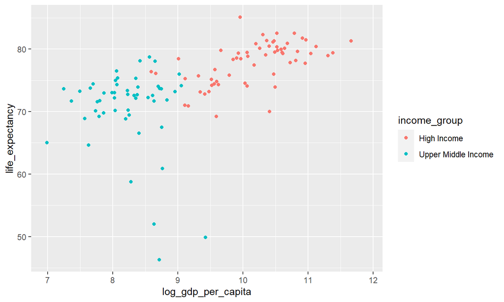

```r
datosONU_tidy %>%
  # seleccionar variables
  select(country_name, income_group, year, gdp_per_capita,
         life_expectancy) %>%
  # filtrar observaciones
  filter(income_group %in% c("Upper Middle Income", "High Income"), year == 2007)  %>%
  # crear nueva variable a partir de una de las seleccionadas
  mutate(log_gdp_per_capita = log(gdp_per_capita)) %>%
  # generar gráfico
  ggplot(aes(x = log_gdp_per_capita, y = life_expectancy, col = income_group)) +
  geom_point()
```

## Respuesta (ii)

```r
datosONU_tidy_ej %>%
  # Cambiar nombre de columnas
  rename("pais" = "country_name",
    "grupo_ingresos" = "income_group",
    "anio" = "year",
    "total_poblacion" = "population_total") %>%
  # Dejar solo observaciones del año 2007
  filter(anio == 2007) %>%
  # Calcular población mundial
  summarise(poblacion_mundial = sum(total_poblacion, na.rm = TRUE))
```

```
## # A tibble: 1 x 1
##   poblacion_mundial
##               <dbl>
## 1        6622799109
```

## Respuesta (iii)

```r
datosONU_tidy_ej %>%
  # Dejar solo observaciones del año 2007
  filter(anio == 2007) %>%
  # Agrupar observaciones por región
  group_by(region) %>%
  # Calcular número de paises y población por región
  summarise(poblacion_regional = sum(total_poblacion, na.rm = TRUE), n_paises = n()) %>%
  # Calcular población promedio por país y región
  mutate(promedio_pob = poblacion_regional/n_paises)
```

```
## # A tibble: 7 x 4
##   region                          poblacion_regional n_paises promedio_pob
##   <chr>                                        <dbl>    <int>        <dbl>
## 1 East Asia and Pacific                   2136250140       36    59340282.
## 2 Europe and Central Afica                 878169784       57    15406487.
## 3 Latin America and the Caribbean          575047293       41    14025544.
## 4 Middle East and North Africa             357997667       21    17047508.
## 5 North America                            334184023        3   111394674.
## 6 South Asia                              1542806515        8   192850814.
## 7 Sub-saharan Africa                       798343687       48    16632160.
```

## Funciones para trabajar con dos o más *data frames* (i)

### Script

- `Clase03_ManejoDatosII`

## Funciones para trabajar con dos o más *data frames* (ii)

- *mutating joins*
  - `left_join`, `right_join`, `inner_join`, `full_join`
- *filtering joins*
  - `semi_join`, `anti_join`
- *set operations*
  - `intersect`, `union`, `setdiff`

Más información en https://dplyr.tidyverse.org/articles/two-table.html

## *Mutating joins*

- Permiten combinar variables desde distintas tablas
- Generalmente el más utilizado es `left_join`

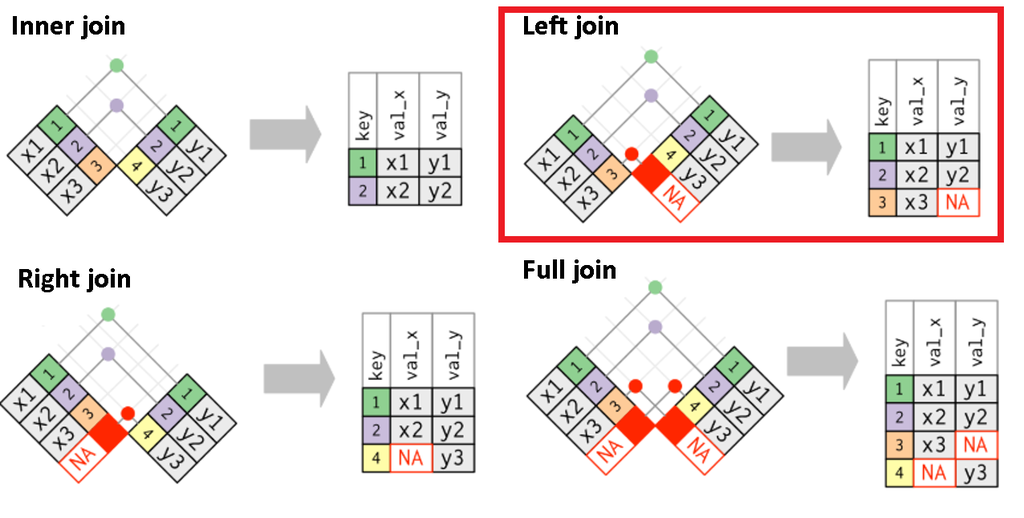

## **Left Join** (i)

Digamos que queremos calcular el promedio de *fertility_rate* para cada *income_group* pero nuestra tabla no tiene información sobre el grupo de ingresos

```r
countries_noincomegroup
```

```
## # A tibble: 7,704 x 3
##    country_name  year fertility_rate
##    <chr>        <dbl>          <dbl>
##  1 Afghanistan   1972           7.67
##  2 Afghanistan   1973           7.67
##  3 Afghanistan   1974           7.67
##  4 Afghanistan   1975           7.67
##  5 Afghanistan   1976           7.67
##  6 Afghanistan   1977           7.67
##  7 Afghanistan   1978           7.67
##  8 Afghanistan   1979           7.67
##  9 Afghanistan   1980           7.67
## 10 Afghanistan   1981           7.67
## # ... with 7,694 more rows
```

## **Left Join** (ii)

Pero si tenemos otra tabla que asocia cada país a su grupo de ingresos

```r
income_group
```

```
## # A tibble: 214 x 2
##    country_name        income_group
##    <chr>               <chr>
##  1 Afghanistan         Low Income
##  2 Albania             Upper Middle Income
##  3 Algeria             Upper Middle Income
##  4 American Samoa      Upper Middle Income
##  5 Andorra             High Income
##  6 Angola              Lower Middle Income
##  7 Antigua and Barbuda High Income
##  8 Argentina           Upper Middle Income
##  9 Armenia             Upper Middle Income
## 10 Aruba               High Income
## # ... with 204 more rows
```

## **Left Join** (iii)

```r
countries_noincomegroup %>%
  left_join(income_group, by = "country_name")
```

```
## # A tibble: 7,704 x 4
##    country_name  year fertility_rate income_group
##    <chr>        <dbl>          <dbl> <chr>
##  1 Afghanistan   1972           7.67 Low Income
##  2 Afghanistan   1973           7.67 Low Income
##  3 Afghanistan   1974           7.67 Low Income
##  4 Afghanistan   1975           7.67 Low Income
##  5 Afghanistan   1976           7.67 Low Income
##  6 Afghanistan   1977           7.67 Low Income
##  7 Afghanistan   1978           7.67 Low Income
##  8 Afghanistan   1979           7.67 Low Income
##  9 Afghanistan   1980           7.67 Low Income
## 10 Afghanistan   1981           7.67 Low Income
## # ... with 7,694 more rows
```

## **Left Join** (iv)

¿Y si los nombres no son iguales?

```r
names(income_group2)
```

```
## [1] "income_group" "country"
```

```r
names(countries_noincomegroup)
```

```
## [1] "country_name"   "year"           "fertility_rate"
```

## **Left Join** (v)

```r
countries_noincomegroup %>%
  left_join(income_group2, by = c("country_name" = "country"))
```

```
## # A tibble: 7,704 x 4
##    country_name  year fertility_rate income_group
##    <chr>        <dbl>          <dbl> <chr>
##  1 Afghanistan   1972           7.67 Low Income
##  2 Afghanistan   1973           7.67 Low Income
##  3 Afghanistan   1974           7.67 Low Income
##  4 Afghanistan   1975           7.67 Low Income
##  5 Afghanistan   1976           7.67 Low Income
##  6 Afghanistan   1977           7.67 Low Income
##  7 Afghanistan   1978           7.67 Low Income
##  8 Afghanistan   1979           7.67 Low Income
##  9 Afghanistan   1980           7.67 Low Income
## 10 Afghanistan   1981           7.67 Low Income
## # ... with 7,694 more rows
```

## **Set operations** (i)

Menos usadas en general pero útiles cuando se requieren

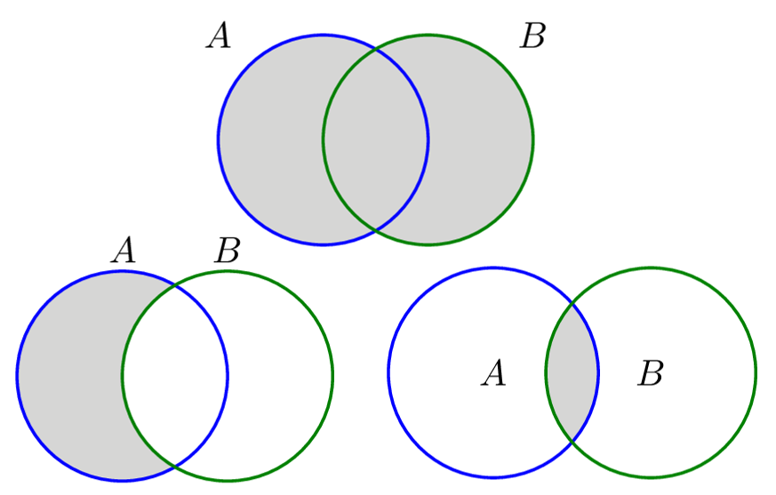

## **Set operations** (ii)

Estas funciones esperan que `x` e `y` tengan las mismas variables/columnas y compara sus observaciones/filas

- `intersect(x, y)`: devuelve solo valores que estén presentes en `x` y en `y`
- `union(x, y)`: devuelve todos los valores (únicos) de `x` y de `y`
- `setdiff(x, y)`: devuelve observaciones que estén en `x` y no en `y`
  - `setdiff(y, x)`: devuelve observaciones estén en `y` y no en `x`

```r
df1 <- datosONU_tidy %>% slice(1:10)
df2 <- datosONU_tidy %>% slice(5:15)
```

## **Set operations** (iii)

La intersección corresponde a las filas 5, 6, 7, 8, 9, y 10 de la base original

```r
intersect(df1, df2)
```

```
## # A tibble: 6 x 17
##   country_name income_group region  year co2_emissions fertility_rate
##   <chr>        <chr>        <chr>  <dbl>         <dbl>          <dbl>
## 1 Afghanistan  Low Income   South~  1976         0.155           7.67
## 2 Afghanistan  Low Income   South~  1977         0.183           7.67
## 3 Afghanistan  Low Income   South~  1978         0.164           7.67
## 4 Afghanistan  Low Income   South~  1979         0.169           7.67
## 5 Afghanistan  Low Income   South~  1980         0.134           7.67
## 6 Afghanistan  Low Income   South~  1981         0.153           7.67
## # ... with 11 more variables: forest_area <dbl>, gdp_per_capita <dbl>,
## #   health_expenditure <dbl>, labor_force_participation <dbl>,
## #   life_expectancy <dbl>, malnutrition_prevalence <dbl>,
## #   population_total <dbl>, urban_population <dbl>,
## #   fossil_fuel_consumption <dbl>, poverty <dbl>,
## #   public_spending_education <dbl>
```

## **Set operations** (iv)

La unión corresponde a las primeras 15 filas de la base original

```r
union(df1, df2)
```

```
## # A tibble: 15 x 17
##    country_name income_group region  year co2_emissions fertility_rate
##    <chr>        <chr>        <chr>  <dbl>         <dbl>          <dbl>
##  1 Afghanistan  Low Income   South~  1972         0.132           7.67
##  2 Afghanistan  Low Income   South~  1973         0.137           7.67
##  3 Afghanistan  Low Income   South~  1974         0.156           7.67
##  4 Afghanistan  Low Income   South~  1975         0.169           7.67
##  5 Afghanistan  Low Income   South~  1976         0.155           7.67
##  6 Afghanistan  Low Income   South~  1977         0.183           7.67
##  7 Afghanistan  Low Income   South~  1978         0.164           7.67
##  8 Afghanistan  Low Income   South~  1979         0.169           7.67
##  9 Afghanistan  Low Income   South~  1980         0.134           7.67
## 10 Afghanistan  Low Income   South~  1981         0.153           7.67
## 11 Afghanistan  Low Income   South~  1982         0.166           7.67
## 12 Afghanistan  Low Income   South~  1983         0.206           7.67
## 13 Afghanistan  Low Income   South~  1984         0.239           7.68
## 14 Afghanistan  Low Income   South~  1985         0.304           7.68
## 15 Afghanistan  Low Income   South~  1986         0.279           7.68
## # ... with 11 more variables: forest_area <dbl>, gdp_per_capita <dbl>,
## #   health_expenditure <dbl>, labor_force_participation <dbl>,
## #   life_expectancy <dbl>, malnutrition_prevalence <dbl>,
## #   population_total <dbl>, urban_population <dbl>,
## #   fossil_fuel_consumption <dbl>, poverty <dbl>,
## #   public_spending_education <dbl>
```

## **Set operations** (v)

Las filas que están en `df1` y no en `df2` corresponden a la 1, 2, 3, y 4 de la base original

```r
setdiff(df1, df2)
```

```
## # A tibble: 4 x 17
##   country_name income_group region  year co2_emissions fertility_rate
##   <chr>        <chr>        <chr>  <dbl>         <dbl>          <dbl>
## 1 Afghanistan  Low Income   South~  1972         0.132           7.67
## 2 Afghanistan  Low Income   South~  1973         0.137           7.67
## 3 Afghanistan  Low Income   South~  1974         0.156           7.67
## 4 Afghanistan  Low Income   South~  1975         0.169           7.67
## # ... with 11 more variables: forest_area <dbl>, gdp_per_capita <dbl>,
## #   health_expenditure <dbl>, labor_force_participation <dbl>,
## #   life_expectancy <dbl>, malnutrition_prevalence <dbl>,
## #   population_total <dbl>, urban_population <dbl>,
## #   fossil_fuel_consumption <dbl>, poverty <dbl>,
## #   public_spending_education <dbl>
```

## **Set operations** (vi)

Las filas que están en `df2` y no en `df1` corresponden a la 11, 12, 13, 14, y 15 de la base original

```r
setdiff(df2, df1)
```

```
## # A tibble: 5 x 17
##   country_name income_group region  year co2_emissions fertility_rate
##   <chr>        <chr>        <chr>  <dbl>         <dbl>          <dbl>
## 1 Afghanistan  Low Income   South~  1982         0.166           7.67
## 2 Afghanistan  Low Income   South~  1983         0.206           7.67
## 3 Afghanistan  Low Income   South~  1984         0.239           7.68
## 4 Afghanistan  Low Income   South~  1985         0.304           7.68
## 5 Afghanistan  Low Income   South~  1986         0.279           7.68
## # ... with 11 more variables: forest_area <dbl>, gdp_per_capita <dbl>,
## #   health_expenditure <dbl>, labor_force_participation <dbl>,
## #   life_expectancy <dbl>, malnutrition_prevalence <dbl>,
## #   population_total <dbl>, urban_population <dbl>,
## #   fossil_fuel_consumption <dbl>, poverty <dbl>,
## #   public_spending_education <dbl>
```

## Ejercicios para la casa

- `Clase03_EjercicioDosTablas.R`
- Guía subida a CANVAS
  - `Ejercicios_dplyr_ggplot`

## ¿Qué se viene?

- Idea de trabajo: hasta mañana a las 23:59
- Tarea 1: Hasta el sábado a las 23:59
- Próxima clase: `tidyr`
  - Transformar bases de datos